# Statistics Using R - UCC

Adam Kane

4 November 2016

# Statistics Defined

The practice or science of collecting and analysing numerical data in large quantities, especially for the purpose of inferring something about the nature of the population from a representative sample.

# Variables

A variable is something that can take on different values e.g. height is a variable. The opposite of variables are constants e.g. the gravitational constant which has one value only.

## Types of variables

In statistics we can consider many types of variables but we can think of 2 broad categories, continuous and categorical. In R we can use the function **class** to identify the kind of variables that we have stored in a vector.

### Categorical variables

For example, classifying where people live in the USA by state. In this case there will be 50 ‘levels’ of the categorical variable.

```r
categoricalVariables <- c("Alaska", "Florida", "New York", "Washington", "Texas")
class(categoricalVariables)
```

```
[1] "character"
```

### Continuous variables

are variables for which their central characteristic is that they can be measured along a continuum and they have a numerical value (for example, temperature).

```r
continuousVariables <- c(30,31,29,30,29,33,34,35)
class(continuousVariables)
```

```
[1] "numeric"
```

# Histograms and distributions

A histogram is a type of graph used to display a distribution. It helps us to overcome the natural tendency to rely on summary information, such as an average. Histograms can reveal information not captured by summary statistics. Histograms are generated in R using the function **hist**

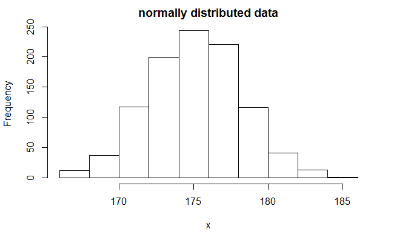

```r
x<-rnorm(1000, mean = 175, sd = 3)
hist(x, main = "normally distributed data")
```

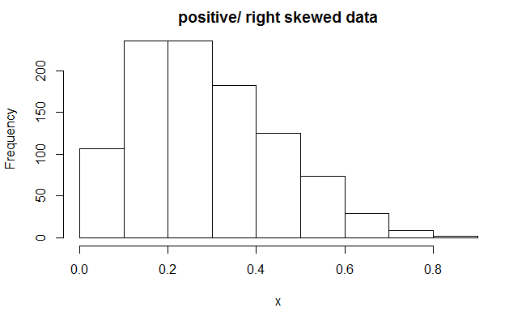

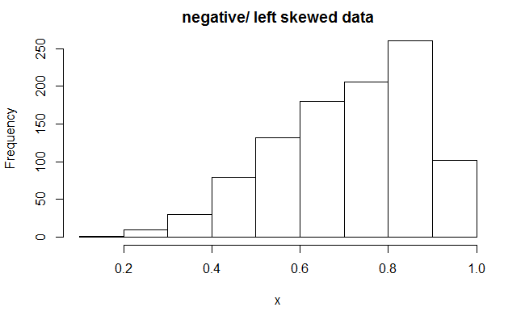

You use the empirical distribution (i.e. the histogram) if you want to describe your sample, and probability density functions if you want to describe the hypothesized underlying distribution. These are things like normal distriubtions which are well defined.

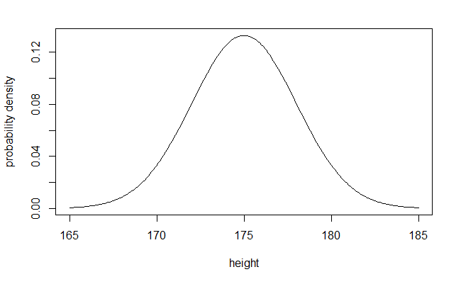

# Summary Statistics

## Central Tendency

### The mean

is a measure of central tendency this describes the middle or centre point of a distribution

$$mean = M = \frac{1}{n} \sum_n^{i =1} x$$

### The median

is the middle score (the score below which 50% of the distribution falls) preferred when there are extreme scores in the distribution

### The mode

is the score that occurs most often in the distribution, useful for nominal variables

### How the distribution can affect measures of central tendency

Differing distribution may mean these three measures do not overlap Here the mean is blue, the median grey and the mode red.

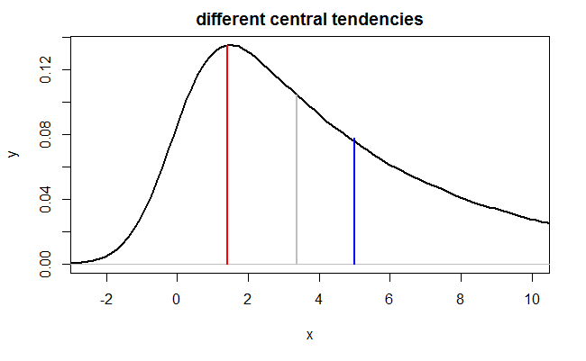

## Measures of Variability

a measure that describes the range and diversity of scores in a distribution

### variance

sum of squared deviation scores = sum of squares are divided by the sample size = mean sum of squares

$$\frac{\Sigma(X-M^2)}{N}$$
is used for descriptive statistics

$$\frac{\Sigma(X-M^2)}{n-1}$$
is used for inferential statistics

### standard deviation

the average deviation from the mean in a distribution

$$\sqrt\frac{\Sigma(X-M^2)}{N}$$
is used for descriptive statistics

$$\sqrt\frac{\Sigma(X-M^2)}{n-1}$$
is used for inferential statistics

### Why n-1 and not N?

The sample mean is not the population mean. The sample mean is “closer” to the sample data than the population mean, so the variance calculated is smaller. Using n-1 corrects for that because it will increase the value for variance.

This n-1 is related to the degrees of freedom (d.f.). This important concept in statistics is defined as follows:

d.f. = n - k,

which is the sample size, n, minus the number of parameters, k, estimated from the data. For the variance, we have estimated one parameter from the data, the sample mean, and so there are n - 1 degrees of freedom.

### How variable is Wayne Rooney

We can calculate some summary statistics for the goals he has scored for Manchester United

here are the points he scored for the seasons he played:

```r
goalsPerSeason<-c(11,16,14,12,12,26,11,27,12,17,12,8,1)
```

we take the sum of those values and the sample size i.e. number of seasons he played to get the mean

```r
sum(goalsPerSeason)
```

```
[1] 179
```

```r
length(goalsPerSeason)
```

```
[1] 13
```

so the mean is

```r
sum(goalsPerSeason)/length(goalsPerSeason)
```

```
[1] 13.76923
```

then the deviation scores show how much he deviated from the mean for each season i.e. it is the difference between a raw score and the mean.

```r
goalsPerSeason - mean(goalsPerSeason)
```

```
 [1]  -2.7692308   2.2307692   0.2307692  -1.7692308  -1.7692308  12.2307692  -2.7692308  13.2307692
 [9]  -1.7692308   3.2307692  -1.7692308  -5.7692308 -12.7692308
```

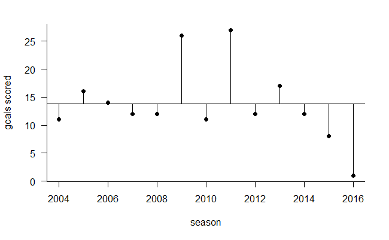

we can’t get the average for the deviation scores because they sum to zero

```r
deviationScores<- goalsPerSeason - mean(goalsPerSeason)
devsum <- sum(deviationScores)
```

[output not shown]

instead we square the deviation scores, sum them and divide by N to give us a score for variance.

That is to say we calculate mean squares because it is the sums of squares divided by N.

$$variance = \frac{\Sigma(X-M^2)}{N}$$

```r
(goalsPerSeason - mean(goalsPerSeason))^2
```

```
 [1]   7.66863905   4.97633136   0.05325444   3.13017751   3.13017751 149.59171598   7.66863905
 [8] 175.05325444   3.13017751  10.43786982   3.13017751  33.28402367 163.05325444
```

```r
devSq <- (goalsPerSeason - mean(goalsPerSeason))^2
devSumSq <- sum(devSq) ; devSumSq
```

```
[1] 564.3077
```

```r
variance <- devSumSq/length(goalsPerSeason) ; variance
```

```
[1] 43.40828
```

Squaring however does have a problem as a measure of spread and that is that the units are all squared, whereas we might prefer the spread to be in the same units as the original data (think of squared goals scored). Hence the square root allows us to return to the original units, which is the standard deviation.

$$SD = \sqrt\frac{\Sigma(X-M^2)}{N}$$

```r
sqrt(variance)
```

```
[1] 6.588496
```

Thankfully, in R we can do all this with the inbuilt functions **mean**, **sd**, and **var** for the mean, sample standard deviation and sample variance respectively.

```r
mean(goalsPerSeason)
```

```
[1] 13.76923
```

```r
sd(goalsPerSeason)
```

```
[1] 6.857524
```

```r
var(goalsPerSeason)
```

```
[1] 47.02564
```

Notice that the values are slightly different here because we are dividing by n - 1 rather than just n.

# Exercise 1

Using the following vectors of data draw a histogram of each variable, calculate their mean and their standard deviation.

```r
height <- c(163, 185, 155, 195, 168, 198, 200, 146, 179, 160, 180, 170)
weight <- c(65, 85, 70, 120, 73, 100, 103, 50, 81, 64, 90, 78)
```

# Standardised Scales

### z-scores

In statistics there is a standard scale the Z scale. Any score from any normally distributed data can be converted to Z scores

$$Z = \frac{(X-M)}{SD}$$

X = raw score, the score on the original scale

M = mean

SD = standard deviation

The mean Z-score is Z = 0

Positive Z scores are above average

Negative Z scores are below average

For example

```r
X = 99.6 # body temp for one person
M = 98.6 # the mean for the group
SD = 0.5 # the standard deviation for the group
Z=(X-M)/SD; Z
```

```
[1] 2
```

This value of 2 means their score is 2 standard deviations above the mean

### z-Distribution

Things to note about a normal distribution. 50% of the data fall above the mean and 50% below. The majority of the data fall between 2 standard deviations above and below the mean. If you are higher or lower than these values then you are an extreme point. This allows for predictions about the distribution because we know predictions aren’t certain rather they are probabilistic.

A z-distribution is a standardised normal distribution wiith a mean of 0 and a standard deviation of 1. If Z = 0 then the percentile rank = 50th which represents percentage of scores that fall at or below a score in a distribution. Thus 50% of the distribution falls below the mean

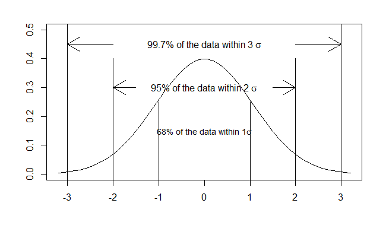

We can use R functions **pnorm** and **qnorm** on our normal distribution so we can get a better handle on what it’s saying. The function **pnorm** returns the area under the curve of our normal distribution from negative infinity to the Z score we specify.

The **pnorm** function also takes the argument **lower.tail**. If **lower.tail** is set equal to **FALSE** then **pnorm** returns the area under the curve from the Z score to positive infinity.

```r
pnorm(0)
```

```
[1] 0.5
```

```r
pnorm(2)
```

```
[1] 0.9772499
```

```r
pnorm(2, lower.tail = FALSE)
```

```
[1] 0.02275013
```

**qnorm** can be thought of as the inverse of **pnorm** and so will return Z-scores from the distribution.

```r
qnorm(0.5)
```

```
[1] 0
```

```r
qnorm(0.9772499)
```

```
[1] 2.000001
```

We can also specify the values of the distribution so it’s not a standard normal by supplying the mean and standard deviation to the function.

```r
pnorm(4,mean=4,sd=2)
```

```
[1] 0.5
```

```r
qnorm(0.5,mean = 4, sd=2)
```

```
[1] 4
```

## t-distributions

Typically we don’t know the standard deviation of the population, rather we calculate a standard deviation from the sample data. In this case, when it comes to making inferences about our sample statistics, we use t-distributions instead of z-distributions.

The t-distribution comes from a family that are dependent on the sample size. As your sample size gets smaller your t-distribution gets a little wider which means you need a larger t-value to get out into the extremes. As your sample size gets bigger your t-ditribution gets closer and closer to the normal distribution.

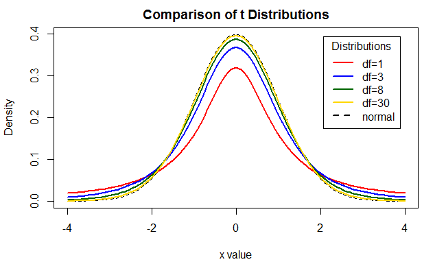

The various t-distributions have equivalents to **pnorm** and **qnorm** with **pt** and **qt** respectively. The only difference is that you have to supply the degrees of freedom which is your sample size minus the number of parameters you’ve estimated.

```r
pt(0, df = 5)
```

```
[1] 0.5
```

```r
qt(0.5, df=5)
```

```
[1] 0
```

# Exercise 2

The following distribution has a mean of 5 and a standard deviation of 1. Using **pnorm** find the area under the curve from negative infinity to 4. How many standard deviations is 4 away from the mean?

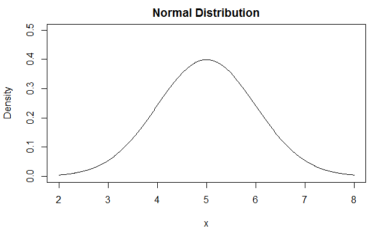

# Sampling

We want the sample we take from a population to be random and representative.

## Sampling error

**sampling error is the error caused by observing a sample instead of the whole population.**

This is important because we can’t get everyone/everything in the popualtion. Thus there will be some fluctuation in the samples we get due to sampling error.

## Estimating sampling error

Sampling error mainly depends on the size of the sample, relative to the size of the population.

As sample size increases, sampling error decreases. It also depends on the variance in the population (which we don’t know).As variance increases, sampling error increases.

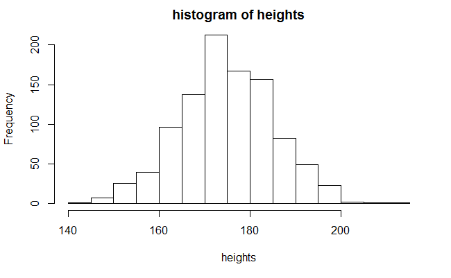

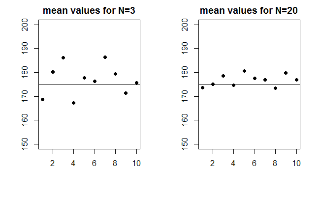

### Standard error of the mean

Usually you won’t have multiple samples to use in making multiple estimates of the mean. Fortunately, you can estimate the standard error of the mean using the sample size and standard deviation of a single sample of observations.

Standard error is an estimate of the average amount of sampling error e.g. for a sample mean

$$SE = \frac{SD}{\sqrt{n}}$$

SE = standard error

SD = standard deviation of the sample

n = Size of the sample

We can see from here that as the sample size in the denominator increases then the standard error is going to decrease.

By contrast, as the standard deviation increases (which should reflect the population standard deviation) so too will the standard error.

Whereas standard deviation describes the variability of the individual observations standard error shows the variability of the estimator e.g. the mean.

# Null Hypothesis Significance Testing (NHST)

NHST is a procedure for hypothesis testing. We can consider NHST as a game where step 1 is the identification of the null hypothesis and the alternative hypothesis.

### Step 1

for a correlational study

$H_0$ = null hypothesis, e.g. the correlation = 0

$H_A$ = alternative hypothesis, e.g. the correlation is > 0

If the alternative hypothesis predicts the direction of the relationship between X & Y (positive Vs negative) it is termed a directional test (aka a one-tailed test)

Alternatively we could be agnositc and not have any idea about the direction of the relationship. In this case it would be a non-directional test (aka a two-tailed test)

### Step 2

Assume $H_0$ is true, then calculate the probability of observing data with these characteristics, given that $H_0$ is true. This can be confusing because it’s the opposite way you’d approach a study. For instance, Jonas Salk didn’t predict his vaccination would have no effect.

$$p=P(D|H_0)$$

**The p-value is the probability of the data given the null hypothesis is true.** If the p-value is very low, then reject $H_0$, else retain $H_0$

A threshold value for p, called the significance level of the test is typically set at 5% and denoted as $\alpha$. If the p-value is less than or equal to the chosen significance level $\alpha$, the test suggests that the observed data is inconsistent with the null hypothesis, so the null hypothesis must be rejected. If we reject the null hypothesis we are saying that the difference between the observed sample statistic (e.g. a sample mean) and the hypothesized population parameter (e.g. a popualation mean) is too great to be attributed to chance.

# 4 possible outcomes of NHST

Either the null is true or it’s false and then, as scientists, we have to successfully pick this out.

[output not shown]

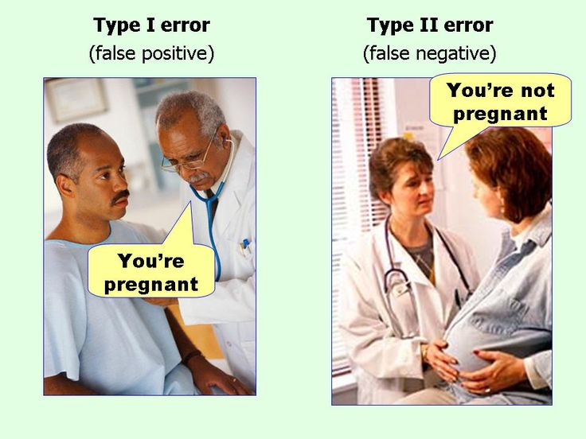

.

## NHST Overview

$$p=P(D|H_0)$$

Given that the null hypothesis is true, the probability of these, or more extreme data, is p.

This does not mean the probability of the null hypothesis being true in p.

In other words,
$$P(D|H_0)!=P(H_0|D)$$

## Sampling Distributions

The sampling distribution is a distribution of a sample statistic. While the concept of a distribution of a set of numbers is intuitive, the concept of a distribution of a set of statistics is not. Rather than using NHST on distributions of individuals we use NHST on distributions of sample statistics. A sampling distribution is a distribution of sample statistics, obtained from multiple samples, for example, a distribution of sample means, of sample correlations, or of sample regression coefficients.

## Central Limit Theorem

Let’s say we have a normal population of data representing heights with a mean of 175 cm and a standard deviation of 5 cm. We then repeatedly take 30 data points from this and calculate a mean of each one. Then we plot this to get a distribution of means.

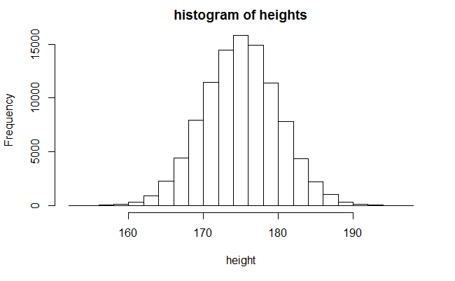

```r
data.set <- rnorm(100000,175,5)
hist(data.set,xlab = "height", main = "histogram of heights")
```

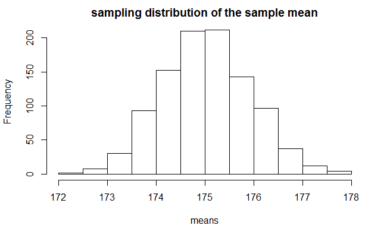

```r
out <- replicate( 1000, mean( sample(data.set, 30) ) )
hist(out, main="sampling distribution of the sample mean",xlab = "means")
```

```r
mean(out)
```

```
[1] 175.0254
```

```r
SD.mean <- sd(data.set) / sqrt(30)
```

The central limit states that this distribution of means will be normally distributed if the distribution of the raw data is normally distributed (as it is here). But even if the population is not normally distributed our sampling distribution will still be approximately normal so long as our sample size is large enough > 30. The central limit theorem also states that the mean of a sampling distribution is the same as the mean of the population and the standard deviation of the sample means equals the standard error of the population mean.

$$\sigma_{\bar{X}}=\frac{\sigma}{\sqrt{n}}$$

http://mfviz.com/central-limit/

This foundational theory in statistics is what allows us to make inferences about populations based on an individual sample. Given our understanding of the normal distribution, we can easily discuss the probability of a value occuring given a mean. **In statistics we use ‘Null distributions’ which are the sampling distributions of our statistics under the null hypothesis.**

## Putting this all together

Say we have a sample of 50 batteries that last for a mean of 97 hours. Assuming that the standard deviation of the population is known to be 10 hours use a 0.05 significance level (the $\alpha$ for our p-value) to test the claim that the population mean of all such batteries is 100 hours. So our null $H_0$ is that the batteries last for 100 hours and our alternative hypothesis $H_A$ is that they last for less than 100 hours.

Using this information we know what the null distribution of the means would look like. It will have a mean of 100 and a standard deviation equal to the standard error of the sample, which is the standard deviation divided by the square root of the sample size. Then the z-score for our sample mean is our sample mean minus the mean under the null hypothesis (100 hours) divided by the standard error:

```r
z <- (97 - 100) / (10/sqrt(50)) ; z
```

```
[1] -2.12132
```

Then we can use pnorm to find the probability of getting a z-score of -2.12132.

```r
pnorm(-2.12132)
```

```
[1] 0.01694744
```

```r
qnorm((1-0.95))
```

```
[1] -1.644854
```

If we found our sample had a battery life of 100 hours i.e. equal to the mean the calculation for our z-score would become:

```r
z <- (100 - 100) / (10/sqrt(50)) ; z
```

```
[1] 0
```

and this would give us a p-value of:

```r
pnorm(0)
```

```
[1] 0.5
```

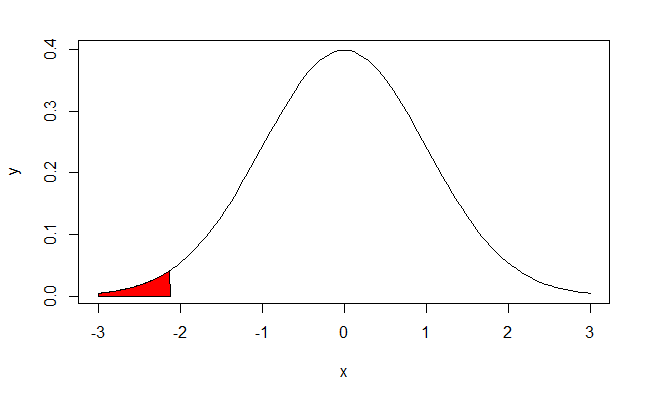

In the above example, we knew the standard deviation of the population but this is generally not known. So instead, we use t-values and the t-distributions but the logic is the same.

# t-tests

Essentially what we’ve been doing here are z-tests and t-tests. These tests are commonly used to determine whether the mean of a population significantly differs from a specific value (called the hypothesized mean) or from the mean of another population.

Let’s assume a simple experimental design where we have a categorical independent variable with two levels and a continuous dependent variable. This will give us two means that can be compared using a t-test. NHST can be conducted, yielding a p-value.

$z=(observed-expected)/SE$

$t=(observed-expected)/SE$

Where SE is standard error, but remember that the standard deviation in the formula for SE will be different for each.

## When to use z and t?

A z-test is used when comparing a sample mean to a population mean when the standard deviation of the population is known.

A single sample t-test is used when comparing a sample mean to a population mean when the standard deviation of the population is unknown.

A dependent t-test is used when evaluating the difference between two related samples (e.g. when the same people are measured twice).

An independent t-test is used when evaluating the difference between two independent samples.

| test | observed | expected | SE |
| --- | --- | --- | --- |
| z | sample mean | population mean | SE of the mean |
| t (single sample) | sample mean | population mean | SE of the mean |
| t (dependent) | sample mean of difference scores | population mean of difference scores | SE of the difference |
| t (independent) | difference between two sample means | difference between two population means | SE of the difference between means |

For the dependent t-test we get difference scores at the level of the individual and for the independent t-test we get difference scores at the level of the group.

## p-values for z and t

Exact p-value depends on:

Directional or non-directional test

Degrees of freedom (df): different t-distributions for different sample sizes

## degrees of freedom for z and t tests

| test | df |
| --- | --- |
| z | NA |
| t (single sample) | N-1 |
| t (dependent) | N-1 |
| t (independent) | (N1-1)+(N2-1) |

# Dependent t-tests

Also known as paired samples t-test. This is appropriate when the same subjects are being compared e.g. pre/post design. Or when two samples are matched at the level of individual subjects, allowing for a difference score to be calculated.

The t-value:

t= (observed - expected)/SE

t=(M-0)/SE=M/SE

Calculate a difference score for each individual and then average them. The expected value under NHST is 0. So it comes down to what did you observe relative to what you would expect due to chance.

Let’s look at an example of film ratings to see if there was a difference in ratings for Star Wars vs Lord of the Rings. The function for a t-test in R is **t.test**

```r
x<-rnorm(100,80,1)
y<-rnorm(100,82,1)
t.test(x,y, paired =T)
```

```
    Paired t-test

data:  x and y
t = -11.648, df = 99, p-value < 2.2e-16
alternative hypothesis: true difference in means is not equal to 0
95 percent confidence interval:
 -2.145164 -1.520698
sample estimates:
mean of the differences
              -1.832931
```

Negative value for t is because of the order. It’s arbitrary to the order we chose our x and y.

# Independent t-tests

Compares two independent samples e.g. males and females, control and experimental etc.

t-value

t=(Observed - Expected)/SE

t=(M1-M2)/SE

SE=(SE1+SE2)/2

# Extra step for indepenent t

Homogeneity of variance is assumed for an indepdent t-test. The pooled SD is appropriate only if the variances in the two groups are equivalent. If not, then the homogeneity of variance assumption is violated. Simulations indicate this results in an increased probability of tpe 1 error.

We can detect a violation of this assumption using Levene’s test. If this is significant then the homogeneity of variance is violated. If it is violated we can adjust the df and p-value using Welch’s procedure, which can protect against type 1 error, or we can use a non-parametric test.

```r
# example with equal variance
library(car)
sample1<-rnorm(100,50,1)
sample2<-rnorm(100,50,1)
y <- c(sample1, sample2)
group <- as.factor(c(rep(1, length(sample1)), rep(2, length(sample2))))
leveneTest(y,group)
```

```
Levene's Test for Homogeneity of Variance (center = median)
       Df F value Pr(>F)
group   1  0.0136 0.9074
      198
```

```r
# independent t test
t.test(y~group,var.equal = T)
```

```
    Two Sample t-test

data:  y by group
t = 0.36899, df = 198, p-value = 0.7125
alternative hypothesis: true difference in means is not equal to 0
95 percent confidence interval:
 -0.2325310  0.3395789
sample estimates:
mean in group 1 mean in group 2
       50.17917        50.12565
```

```r
#example with unequal variance
sample1<-rnorm(100,50,1)
sample3<-rnorm(100,50,4)
y1 <- c(sample1, sample3)
group <- as.factor(c(rep(1, length(sample1)), rep(2, length(sample3))))
leveneTest(y1,group)
```

[output not shown]

Conducting multiple t-tests is tedious and increases the probability of Type 1 error. Instead, when there are more than two group means to compare, conduct analysis of variance (ANOVA).

# Exercise 3

We take a group of 11 patients and want to test the effect of a drug on their test scores before and after their treatment. First, draw a boxplot **boxplot** and calculate the means of each of the samples, then conduct a t test to see if there is an effect.

```r
before<-c(30,68,45,60,79,40,55,49,82,44,76)
after<-c(70,68,50,59,81,44,78,53,90,87,80)
```

# Confidence Intervals

## Confidence intervals around sample means

The logic of confidence intervals is to report a range of values, rather than a single value. The sample mean we calculate will not match up exactly with the population mean. This is because of sampling error. However, we do have an idea of how variable our sample means can be because we can estimate standard error. This is equivalent to the standard deviation of the sampling distribution of sample means.

Based on the Central Limit Theorem and rules the normal distribution, we know that approximately 95% of our sample means will be within 1.96 standard errors of the true population mean in our sampling distribution of the sample means i.e. within the shaded area (at 99% we would cover a wider area). The critical value $\alpha$ is 1 minus the confidence coefficient which we’ve set at 0.95. We take this $\alpha$ value and divide it evenly among both tails so that we have 2.5% of 0.025.

But this sampling distribution is a useful fiction. In practice we have a sample mean and a measure of standard error. We use the point estimate of the sample mean we have along with the critical value and standard error estimate (the latter 2 of which are know as the margin of error). This allows us to create a confidence interval around the point estimate.

The general form of a confidence interval is: point estimate $\pm$ margin of error, where the margin of error is Z * the standard error of the point estimate. The 95% confidence interval for the population mean, can also be expressed as:

$$\bar{X}\pm 1.96 \frac{\sigma}{\sqrt{n}}$$

The width of a confidence interval is influenced by sample size (as sample size increases you can be more confident that the interval will contain the estimate) and variance in the population (and sample). That is to say that standard error influences the width of the confidence intervals.

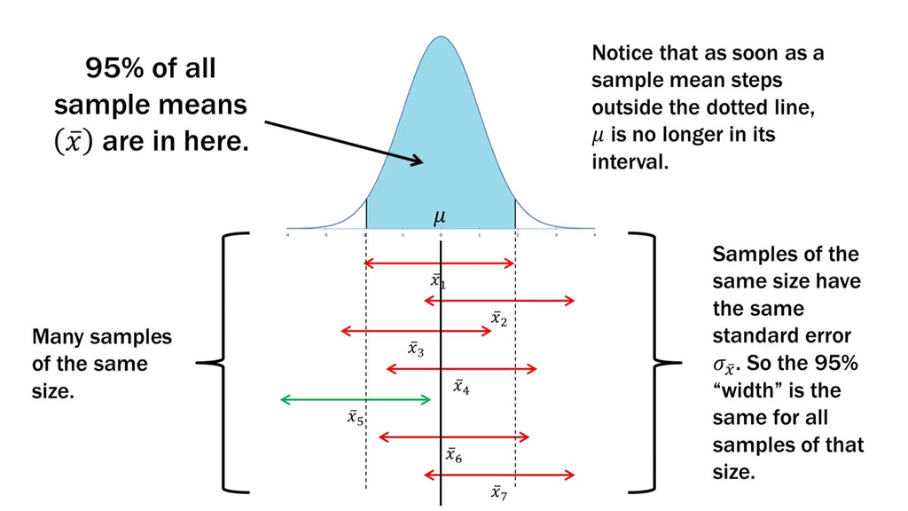

.

However, because we’re using a 95% confidence interval we may be unlucky when we calculate them such that they won’t capture the population parameter. There are going to be times that we get a sample that is not representative of the population and therefore it will not contain the population mean. 95 % confidence is a confidence that in the long-run 95 % of the confidence intervals will include the population mean. It is a confidence in the algorithm and not a statement about a single confidence interval. **Thus it is not correct to say that your interval has a 95% chance of containing the population parameter.** It either does or it doesn’t.

### Why don’t we use a confidence level of 100%?

Wouldn’t it be better to be right 100% of the time rather than 95% of the time? Not necessarily, when it comes to confidence intervals. The problem is that (for a given n and standard deviation), the smaller we make $\alpha$ the wider the CI becomes (think of the area in blue expanding outward). It is possible to construct a 100% confidence interval, but it is infinitely wide, and therefore tells us nothing.

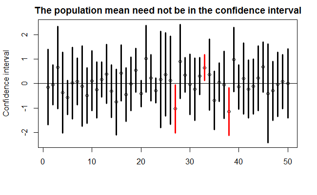

### Example of a confidence interval when the population standard deviation is known

Here we assume that the sample mean is 5, the standard deviation of the population is 2, and the sample size is 30. In the example below we will use a 95% confidence level and wish to find the confidence interval. The commands to find the confidence interval in R are the following:

```r
mean <- 5
standardDeviation<- 2
n <- 30
error <- 1.96*standardDeviation/sqrt(n)
# when you find that the z-score for a given observation equals 1.96, you know that
# the probability of finding a value at or above that value is 0.025 and below is 1-0.025 = 0.975).
# Can use qnorm(0.975) to find this
left <- mean-error
right <- mean+error
left
```

```
[1] 4.284309
```

```r
right
```

```
[1] 5.715691
```

### Example of a confidence interval when the population standard deviation is unknown

Calculating the confidence interval when we don’t know the population standard deviation is similar to using a z-distribution. The only differences are that we use the t-distribution rather than the z-distribution and we use sample standard deviation rather than population standard deviation. Here we repeat the procedures above, but we will assume that we are working with a sample standard deviation rather than an exact standard deviation.

[figure not shown]

```r
mean <- 5
standardDeviation <- 2
n <- 30
error <- qt(0.975,df=n-1)*standardDeviation/sqrt(n)
left <- mean-error
right <- mean+error
left
```

```
[1] 4.253188
```

```r
right
```

```
[1] 5.746812
```

This produces a mean of 5 with a 95% confidence interval ranging from 4.253188 to 5.746812

http://rpsychologist.com/d3/CI/

# Exercise 4

To estimate the mean amount spent by customers in a restaurant, data was collected for 75 customers. We assume the population standard deviation is 4 euro.

1. At the 95% confidence, what is the margin of error?
2. If the sample mean is 20 euro, what is the 95% confidence interval for the population mean (all customers)?

# Correlation

A statistical procedure used to measure and describe the relationship between two variables

Correlations can range between +1 and -1

+1 is perfect positive correlation

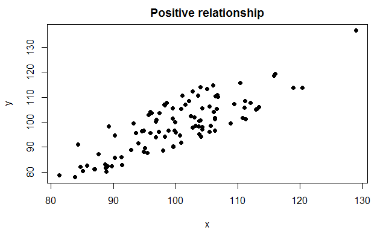

0 is no correlation (independence)

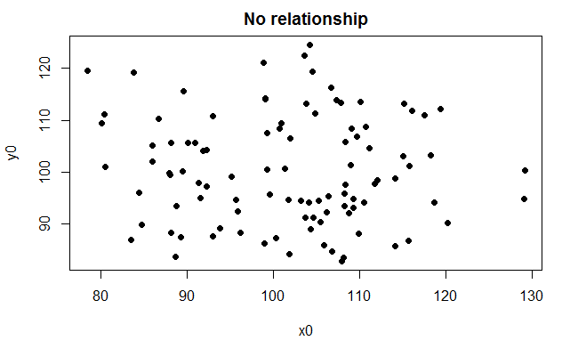

-1 is perfect negative correlation

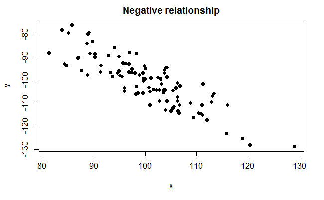

When two variables, let’s call them X and Y, are correlated, then one variable can be used to predict the other variable. More precisely, a person’s score on X can be used to predict his or her score on Y. For example, working memory capacity is strongly correlated with intelligence, or IQ, in healthy young adults. So if we know a person’s IQ then we can predict how they will do on a a test of working memeory. We can see in this scatterplot that there is a positive correlation in our data, which is verified by the value we get for our correlation.

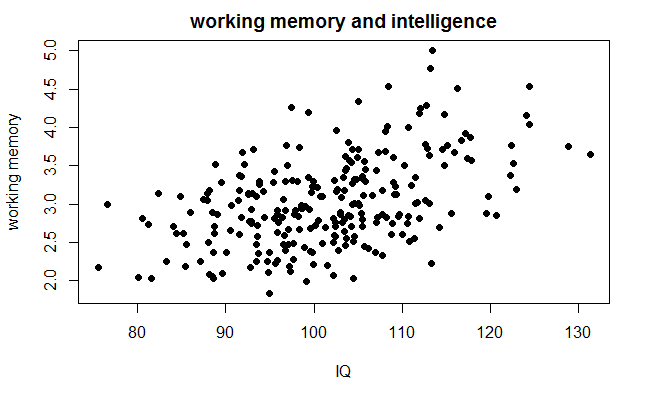

```r
IQ <- rnorm(250, mean = 100, sd = 10)
workingMemory <- IQ*rnorm(250, mean = 3, sd = 0.5)/100
df = data.frame(IQ, workingMemory)
plot(df$workingMemory~df$IQ, xlab="IQ" , ylab="working memory", pch = 16, main = "working memory and intelligence")
```

```r
cor.test(df$IQ, df$workingMemory)
```

```
    Pearson's product-moment correlation

data:  df$IQ and df$workingMemory
t = 8.5637, df = 248, p-value = 1.171e-15
alternative hypothesis: true correlation is not equal to 0
95 percent confidence interval:
 0.3759423 0.5681215
sample estimates:
      cor
0.4777272
```

## Warnings about correlation

But we have to remember that correlation does not imply causation. In our example, working memory does not cause IQ and vice versa, rather there are lots of intervening variables. The magnitude of a correlation is influenced by many factors, including: sampling (random and representative?), and the measurement of X & Y (are your measures of IQ reliable?).

When you fail to get a representative sample you can get attenutation of correlation due to a restriction of range in one of your variables. For instance, if you only select college graduates, you have preselected for higher IQ and this can reduce the correlation. This restriction of range essentially restricts variance ultimately impacting our ability to discern covariance. In the following scatterplot and correlation measure you can see this effect.

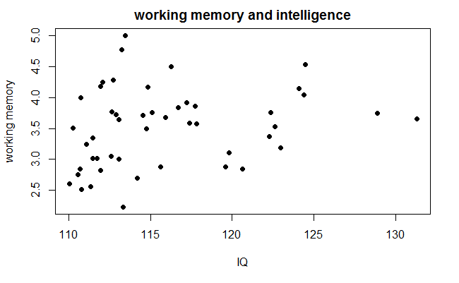

```r
dfAttenuated <- df[df$IQ >110, ]
plot(dfAttenuated$workingMemory~dfAttenuated$IQ, xlab="IQ" , ylab="working memory", pch = 16, main = "working memory and intelligence")
```

```r
cor.test(dfAttenuated$IQ, dfAttenuated$workingMemory)
```

```
    Pearson's product-moment correlation

data:  dfAttenuated$IQ and dfAttenuated$workingMemory
t = 1.6292, df = 46, p-value = 0.1101
alternative hypothesis: true correlation is not equal to 0
95 percent confidence interval:
 -0.05415805  0.48548601
sample estimates:
      cor
0.2335709
```

Finally, a correlation coefficient is a sample statistic just like the mean and won’t be representative unless the correlation coefficient is 1.

## Types of Correlation

There are several types of correlation coefficients, for different variable types.

#### The Pearson product-moment correlation coefficient (r)

This is used when both variables, X & Y, are continuous.

#### The Point bi-serial correlation

This is used when 1 variable is continuous and 1 is dichotomous.

#### The Phi coefficient

When both variables are dichotomous

#### Spearman rank correlation

When both variables are ordinal (ranked data)

## Focus on Pearson correlation

It gives a number termed r which is the degree to which X and Y vary together, relative to the degree to which X and Y vary independently.

### Covariance

Covariance measures the relationship between two variables.

The formula for covariance is:
$$cov(X,Y) = \frac {\Sigma(X-M_x)(Y-M_y)}{N}$$

The numerator is also known as the sum of cross products. It is the product of the deviations of the X and Y values from their respective means.

The covariation can be adjusted for the number of observations by dividing by N (number of cases) to produce the covariance–the average or mean amount that the paired observations covary.

Covariance itself is not scaled, so it can’t tell you the strength of that relationship. To account for this, correlation takes covariance and scales it by the product of the standard deviations of the two variables.

# $$\begin{array}{lcc} r=\frac{\frac {\Sigma(X-M_x)(Y-M_y)}{N}}{\sqrt\frac{\Sigma(X-M_x)^2}{N}\sqrt\frac{\Sigma(Y-M_y)^2}{N}} \end{array}$$

In R, the functions for covariance and correlation are **cov** and **cor.test** respectively.

```r
cov(df$IQ,df$workingMemory) # covariance score
```

```
[1] 2.748265
```

```r
cor.test(df$IQ,df$workingMemory) # correlation score
```

```
    Pearson's product-moment correlation

data:  df$IQ and df$workingMemory
t = 8.5637, df = 248, p-value = 1.171e-15
alternative hypothesis: true correlation is not equal to 0
95 percent confidence interval:
 0.3759423 0.5681215
sample estimates:
      cor
0.4777272
```

### Anscombe’s Quartet

Why it’s critical to look at your scatterplots.

Four datasets where the correlation is exactly the same. The datasets also have the same variance. But clearly there are differences in these datasets.

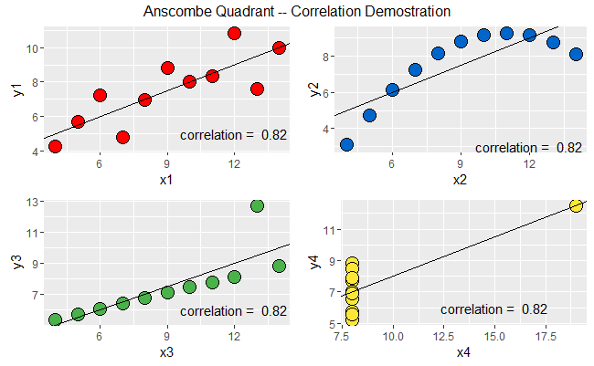

# Exercise 5

Using the following vectors of data plot them against one another and calculate their covariance and correlation. What happens if you switch the order of the variables?

```r
height <- c(163, 185, 155, 195, 168, 198, 200, 146, 179, 160, 180, 170)
weight <- c(65, 85, 70, 120, 73, 100, 103, 50, 81, 64, 90, 78)
```

# Regression

A regression is a statistical analysis used to predict scores on an outcome variable, based on scores on one or multiple predictor variables. It differs from correlation because the variables are no longer interchangeable. In a simple regression there is one predictor variable whereas in a multiple regression there are multiple predictor variables.

## Regression equation

$$Y = m + bX + e$$
this is the equation of a line

Y = a linear function of X

m = intercept

b = slope

e = residual error

other notation, more commonly used for statistics
$$Y = B_0 +B_1X_1 + e$$

Y = a linear function of $X_1$

$B_0$ = intercept = regression constant

$B_1$ = slope = regression coefficient

e = residual error

### Simple regression example

In R, the function for a linear regression model is **lm** and we can use the function **summary** to check the output of the model. We can also plot the data using **plot** and fit a line that best fits the data using **abline**. Note that you have to first plot the data, then call the lm function before you can add the line of best fit.

```r
df = data.frame(body, brain)
plot(df$brain~df$body, xlab="body mass (kg)" , ylab="brain mass (kg)", pch = 16, main = "brain size as a function of body size")
cor.test(df$body, df$brain)
```

```
    Pearson's product-moment correlation

data:  df$body and df$brain
t = 8.6622, df = 248, p-value = 6.037e-16
alternative hypothesis: true correlation is not equal to 0
95 percent confidence interval:
 0.3806483 0.5718293
sample estimates:
      cor
0.4819546
```

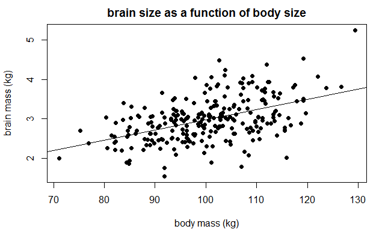

```r
model1 <- lm(df$brain~df$body)
abline(model1)
```

```r
summary(model1)
```

```
Call:
lm(formula = df$brain ~ df$body)

Residuals:
     Min       1Q   Median       3Q      Max
-1.37683 -0.32246 -0.00195  0.29800  1.50948

Coefficients:
            Estimate Std. Error t value Pr(>|t|)
(Intercept)  0.38105    0.30251   1.260    0.209
df$body      0.02599    0.00300   8.662 6.04e-16 ***
---
Signif. codes:  0 â***â 0.001 â**â 0.01 â*â 0.05 â.â 0.1 â â 1

Residual standard error: 0.4886 on 248 degrees of freedom
Multiple R-squared:  0.2323,    Adjusted R-squared:  0.2292
F-statistic: 75.03 on 1 and 248 DF,  p-value: 6.037e-16
```

**The estimate of the slope is 0.02599, so with every one unit (kg) increase in X (body mass) there is a 0.02599 (kg) increase in Y (brain mass).**

**The estimate of the intercept is 0.38105, the predicted score on Y when X = 0.** Thus the regression equation is

$$Y=0.38105+0.02599(body)$$

$R^2$ is the percentage of variation in Y explained by the model. In our case it is the percentage of variation of brain size explained by body size.

In a simple regression the $R^2$ value 0.2323 is equal to the correlation coefficient 0.4819546 to the power of 2.

```r
0.4819546^2
```

```
[1] 0.2322802
```

## Calculation of regression coefficients

Regression equation
$$Y = B_0 + B_1X_1 + e$$

$$\hat{Y} = B_0 + B_1X_1$$
where $\hat{Y}$ is the predicted score for Y

$$Y-\hat{Y} = e(residual)$$

The values of the coefficients (e.g. $B_1$) are estimated such that the regression model yields optimal predictions. What we want to do is minimise the residuals i.e. minimise the prediction error.

```r
x<- c(2000,2001,2002,2003,2004,2005)
y<-c(9.34,8.50,7.62,6.93,6.60,7.2)
m1<-lm(y~x)
fitted<-predict(lm(y~x))
plot(x,y, pch =16, xlim = c(2000,2005), ylim = c(5,10))
abline(m1)
```

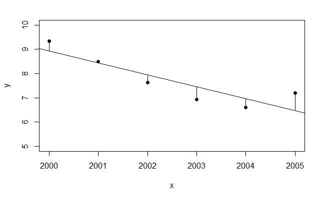

```r
for (i in 1:6) lines(c(x[i],x[i]),c(y[i],fitted[i]))
```

### Ordinary least squares estimation

Minimise the sum of the squared (SS) residuals. The best fit slope is found by rotating the line until the this is minimised.

$$\Sigma(Y-\hat{Y})^2$$

http://setosa.io/ev/ordinary-least-squares-regression/

### Formula for the the slope in a regression model

In a simple linear regression there are a number of ways to calculate the slope. But conceptually, the regression coefficient is the ratio of the covariation between both variables to the variation of the independent variable.

covariance of x & y / variance of x

$$B_1=\frac{\frac {\Sigma(X-M_x)(Y-M_y)}{N}}{\frac{\Sigma(X-M_x)^2}{N}}$$

This regression slope gives a useful quantity interpreted as the estimated change in the expected value of Y for a given value of X. Specifically, it tells you the change in the expected value of Y corresponding to a 1-unit increase in X. This information can not be deduced from the correlation coefficient alone.

#### What is the relationship between b ( the slope) and r (the correlation coefficient)?

$$B_1 = r * (\frac{SD_y}{SD_x})$$

where r is the correlation coefficient.

### Formula for the Intercept in a regression model

We can calculate the intercept $B_0$ in the regression model by using the value we found for the slope along with the mean values for x and y.

$$B_0 = M_y - B_1*M_x$$

Note that if there is no slope (i.e., an increase in X produces no increase in Y), so that $B_1=0$ the second term on the right would also be 0 and the intercept, $B_0$, would be equal to the mean of the dependent variable, Y. Thus, the “slope” in the scatterplot would be a straight line from right to left, drawn at the mean of Y.

### What is the t value?

```r
summary(model1)
```

```
Call:
lm(formula = df$brain ~ df$body)

Residuals:
     Min       1Q   Median       3Q      Max
-1.37683 -0.32246 -0.00195  0.29800  1.50948

Coefficients:
            Estimate Std. Error t value Pr(>|t|)
(Intercept)  0.38105    0.30251   1.260    0.209
df$body      0.02599    0.00300   8.662 6.04e-16 ***
---
Signif. codes:  0 â***â 0.001 â**â 0.01 â*â 0.05 â.â 0.1 â â 1

Residual standard error: 0.4886 on 248 degrees of freedom
Multiple R-squared:  0.2323,    Adjusted R-squared:  0.2292
F-statistic: 75.03 on 1 and 248 DF,  p-value: 6.037e-16
```

t = (the test statistic - the hypothesised value) / the standard error of the statistic. As applied here, the statistic is the sample value of the slope and the hypothesized value is 0. Our null hypothesis is that the slope is 0, our alternative is that it is not 0.

# Assumptions of linear regression

## Linearity

This assumption requires that the dependent variable is a linear combination of the explanatory variables and the error terms . It requires the specified model to be linear in parameters, but it does not require the model to be linear in variables. Here is a linear model which is both, linear in parameter and variables.

$$y = B_0 + B_1X_1+B_2X_2 +\epsilon$$

In order for OLS to work the specified model has to be linear in parameters. Note that if the true relationship between and is non linear it is not possible to estimate the coefficient in any meaningful way.

The following shows a model in which $B_1$ is quadratic

$$y = B_0 + (B_1)^2X_1+B_2X_2+\epsilon$$

However, the assumption does not require the model to be linear in variables. OLS will produce a meaningful estimation of $B_{1}$ in the following:

$$y = B_0 + B_1(X_1)^2+B_2X_2+\epsilon$$

## Normally distributed residuals

There is a very persistent myth that when we assess normality we are referring to the distribution of the original data. This is wrong, when we assess normality we do so with reference to the residuals or errors. This means that in the population, for any particular X you can measure many Y’s, and the Y’s for any particular X are normally distributed.

### Return to Anscombe’s Quartet

The following graphs and their regression coefficients show how similar the four data sets are, even for linear regression models. The regression equation for each is approximately:

$$\hat{Y}=3+0.5(X_1)$$

```
                  lm1      lm2       lm3       lm4
(Intercept) 3.0000909 3.000909 3.0024545 3.0017273
x1          0.5000909 0.500000 0.4997273 0.4999091
```

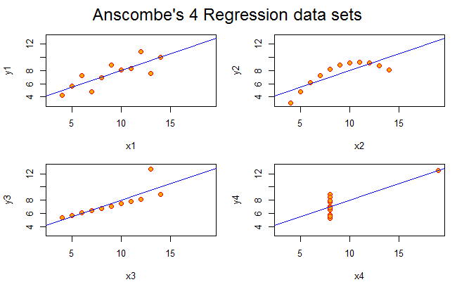

But only the top left panel looks suitable for a linear regression model. The others look like they don’t satisfy the various assumptions of linear regression. In order to test this we can save the residuals of each model using the function **resid**.

$$Y=B_0+B_1+e$$

where

$$e=(Y-\hat{Y})$$

We can then look at the residuals as a function of the X predictor variable. Then we examine a scatterplot with the X variable on the X-axis and the residuals on the Y-axis.

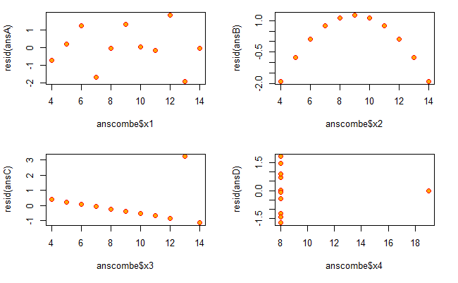

The plot in the top left is what we are looking for. We don’t want any pattern in our residual plot and this suggests no systematic error. The other plots suggest there is a relationship between X and the residual.

## Homoscedasticity and heteroscedasticity

The idea of Homoscedasticity is that our residuals are not related to X, the independent variable. The residuals should be chance errors and not systematic. If the residuals are related to X then we suspect some sort of confound in our study. This is termed Heteroscedasticity.

A classic example of heteroscedasticity is that of income versus expenditure on meals. As one’s income increases, the variability of food consumption will increase. A poorer person will spend a rather constant amount by always eating inexpensive food; a wealthier person may occasionally buy inexpensive food and at other times eat expensive meals. Those with higher incomes display a greater variability of food consumption.

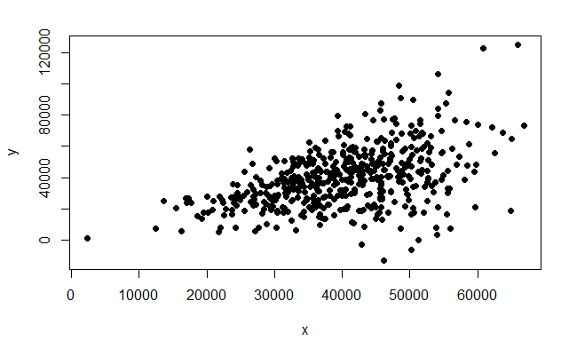

## Independence of errors

Repeated measures through time on the same individual will have non-independent errors because peculiarities of the individual will be reflected in all of the measurements made on it (the repeated measures will be temporally correlated with one another).

Similarly, samples taken from the same vicinity will have non-independent errors because peculiarities of the location will be common to all of the samples (this is spatial autocorrelation).

## Diagnostic Plots

Again R has some inbuilt functions to run diagnostic tests on the the results of your linear regression to see if the model adheres to the assumption. Here we use the **plot** function of our linear model object to plot some diagnostic tests.

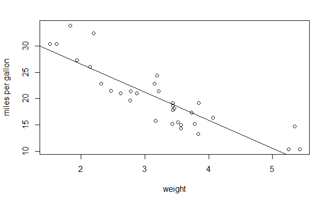

```r
plot(mpg ~ wt, data = mtcars, xlab="weight", ylab="miles per gallon")
fit = lm(mpg ~ wt, data = mtcars)
abline(fit)
```

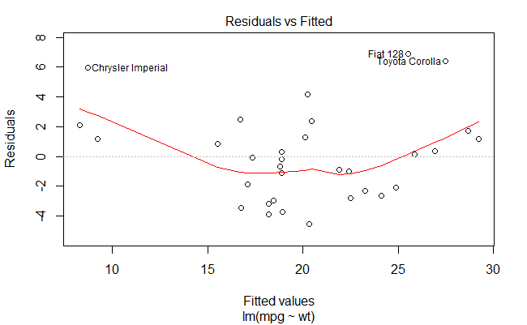

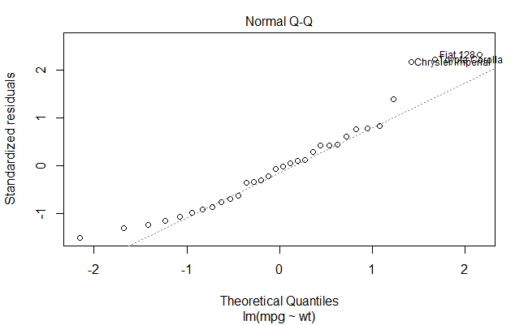

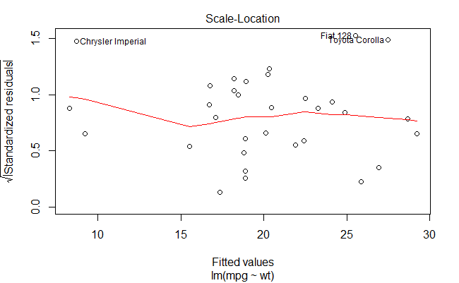

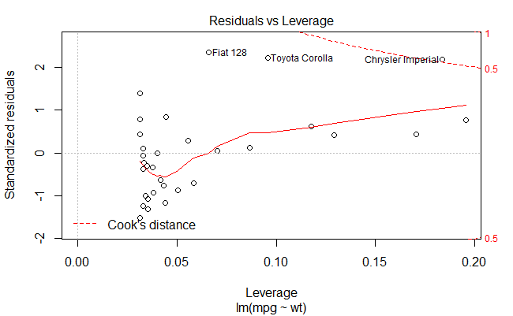

```r
plot(fit)
```

### Residuals vs Fitted values

The first plot shows your Residuals vs Fitted values

This plot shows if residuals have non-linear patterns. There could be a non-linear relationship between predictor variables and an outcome variable and the pattern could show up in this plot if the model doesn’t capture the non-linear relationship. If you find equally spread residuals around a horizontal line without distinct patterns, that is a good indication you don’t have non-linear relationships.

### Normal Q-Q

This plot shows if residuals are normally distributed. Do residuals follow a straight line well or do they deviate severely? It’s good if residuals are lined well on the straight dashed line.

### Scale-Location

It’s also called Spread-Location plot. This plot shows if residuals are spread equally along the ranges of predictors. This is how you can check the assumption of equal variance (homoscedasticity). It’s good if you see a horizontal line with equally (randomly) spread points.

### Residuals vs Leverage

This plot helps us to find influential cases (i.e., subjects) if any. Not all outliers are influential in linear regression analysis (whatever outliers mean). Even though data have extreme values, they might not be influential to determine a regression line. That means, the results wouldn’t be much different if we either include or exclude them from analysis. They follow the trend in the majority of cases and they don’t really matter; they are not influential. On the other hand, some cases could be very influential even if they look to be within a reasonable range of the values. They could be extreme cases against a regression line and can alter the results if we exclude them from analysis. Another way to put it is that they don’t get along with the trend in the majority of the cases.

Unlike the other plots, this time patterns are not relevant. We watch out for outlying values at the upper right corner or at the lower right corner. Those spots are the places where cases can be influential against a regression line. Look for cases outside of a dashed line, Cook’s distance. When cases are outside of the Cook’s distance (meaning they have high Cook’s distance scores), the cases are influential to the regression results. The regression results will be altered if we exclude those cases.

The assumption of a random sample and independent observations cannot be tested with diagnostic plots. It is an assumption that you can test by examining the study design.

# Multiple Regression

In a multiple regression there are multiple predictors (X1,X2,X3…Xn), in contrast to a simple regression where there’s only one predictor.

$$\hat{Y} = B_0 + B_1X_1 + B_2X_2 + ... B_nX_n$$

$\hat{Y}$ = predicted value on the outcome variable Y

$B_0$ = predicted value on Y when all X = 0

$X_k$ = predictor variables

$B_n$ = unstandardised regression coefficients / slopes where n is the number of predictors

$Y - \hat{Y}$ = residual (prediction error)

## Multiple Regression Example

In this example we have data on the salaries of academics and some associated covariates that we want to use to predict salary. We have included a categorical variable for the gender of the academic. We can recode this in R to 1s and 0s but R will also cope with this type of variable automatically (the order is alphabetical)

|  | yrs.since.phd | pubs | salary | sex |
| --- | --- | --- | --- | --- |
| 1 | 19 | 26 | 139750 | 0 |
| 2 | 20 | 31 | 173200 | 0 |
| 3 | 4 | 29 | 79750 | 0 |
| 4 | 45 | 37 | 115000 | 0 |
| 5 | 40 | 31 | 141500 | 0 |
| 6 | 6 | 33 | 97000 | 0 |

The R function for a multiple regression is the same as for a simple regression, **lm**

```r
m1<-lm(data$salary~data$pubs+data$yrs.since.phd+data$sex)
summary(m1)
```

```
Call:
lm(formula = data$salary ~ data$pubs + data$yrs.since.phd + data$sex)

Residuals:
   Min     1Q Median     3Q    Max
-85928 -19482  -3170  15585 101192

Coefficients:
                   Estimate Std. Error t value Pr(>|t|)
(Intercept)         88632.5     6005.3  14.759   <2e-16 ***
data$pubs             150.4      177.2   0.849   0.3965
data$yrs.since.phd    959.4      108.4   8.853   <2e-16 ***
data$sex1           -8536.2     4741.0  -1.801   0.0725 .
---
Signif. codes:  0 â***â 0.001 â**â 0.01 â*â 0.05 â.â 0.1 â â 1

Residual standard error: 27480 on 393 degrees of freedom
Multiple R-squared:  0.1832,    Adjusted R-squared:  0.177
F-statistic: 29.38 on 3 and 393 DF,  p-value: < 2.2e-16
```

We can construct the regression model using the coefficients from the R out put to produce the following:

$$\hat{y} = 88632.5 + 150.4(pubs) + 959.4(PhD) - 8536.2(sex)$$

But, what do these values actually mean? 88632.5 is the intercept of the model and is the predicted salary for a male professor who has no publications and has just graduated from his PhD (predicted score when all X=0).

959.4 is the predicted change in salary associated with an increase in one year since your PhD, for professors who have an average number of publications and averaged across men and women. In a multiple regression you have to take into account the other variables. It’s not simply the predicted change in salary for a unit change in time since PhD. This is often stated as the average change in the y variable for a change in a specific x variable, holding all other variables constant. They are held constant at their mean values as we stated.

According to this model, is the gender difference statistically significant? No because p > 0.05.

# Exercise 6

Given these data, plot them, run a simple linear regression model, draw a line of best fit, write out the resulting regression equation and assess the model using diagnostic tests.

```r
height <- c(163, 185, 155, 195, 168, 198, 200, 146, 179, 160, 180, 170, 190)
weight <- c(65, 85, 70, 120, 73, 100, 103, 50, 81, 64, 90, 78, 71)
```

## General Linear Model and Generalised Linear Model

The General Linear Model is a mathematical framework used in many common statistical analyses, including multiple regression. ANOVA is typically presented as distinct from multiple regression but it IS a multiple regression.

The general linear model requires that the errors follow the normal distribution whilst the generalized linear model is an extension of the general linear model that generalizes the error term distribution to a family of distributions. This family of models uses the **glm** function.

# Chi Square Tests

How to deal with situations where we have a categorical outcome variable e.g. a nominal variable like diagnosis (positive or negative), verdict (guily or innocent) etc. as well as categorical predictors.

The **Chi-square goodness of fit** statistic determines how well a distribution of proportions “fits” an expected distribution.

In election polls, is there a statistically significant difference in voter preference among candidates?

The **Chi-square test of independence** determines whether there is a relationship between two categorical variables.

In election polls, is there a relationship between the gender of the voter and the candidate they prefer i.e. is there a contingency.

## Chi-square goodness of fit

City Mayoral election

Assume a small poll was conducted (N=60) where people were asked do you intend to vote for Joe, Bill or Other?

Let’s assume our results were 23 for Joe, 12 for Bill and 25 for Other.

Our Chi-square goodness of fit tests the null hypothesis that there are equal proportions across those categories.

The alternative hypothesis is that there are unequal proportions.

$$\chi^2=\sum\frac{(O - E)^2}{E}$$

O = observed

E = expected

df = # of categories - 1

p-value depends on $\chi^2$ and df

Just like the family of t-distributions there are a family of chi-square distributions whose shape is determined by df.

| Joe | Bill | Other |
| --- | --- | --- |
| 20 (E) | 20 (E) | 20 (E) |
| 23(O) | 12(O) | 25(O) |

| Subject | O | E | (O-E) | (O-E)^2 | (O-E)^2 / E |
| --- | --- | --- | --- | --- | --- |
| Joe | 23 | 20 | 3 | 9 | 0.45 |
| Bill | 12 | 20 | -8 | 64 | 3.2 |
| Other | 25 | 20 | 5 | 25 | 1.25 |
| Total | 60 | 60 | 0 | 98 | 4.9 |

$\chi^2$ = 4.90, df=2, p = 0.09

Therefore, retain the null hypothesis and conclude that the slight preferences observed here are not statistically significant.

```r
Observed <- matrix(c(23,12,25),nrow = 3,ncol = 1, byrow = T)
chisq.test(Observed)
```

```
    Chi-squared test for given probabilities

data:  Observed
X-squared = 4.9, df = 2, p-value = 0.08629
```

## Chi square test of independence

The Chi-square test of independence determines whether there is a relationship between two categorical variables.

In election polls, is there a relationship between the gender of the voter and the candidate they prefer i.e. is there a contingency? Again, use the example of a mayoral election in a city. We assume a small poll was conducted of 200 people and that there were males than females in the poll (n=140, n=60). The people were asked ‘do you intend to vote for Joe, Bill or other?’ Our null is that there is no relationship between gender and voter preference. Our alternative is that there is a relationship between gender and voter preference.

$$\chi^2=\sum\frac{(O - E)^2}{E}$$

the same as before

df is different and is now (# of rows - 1) * (# of columns -1)

p-value depends on $\chi^2$ and df

We have to compute the expected frequencies. The proportion of male and female voters for each candidates should be the same as the overall voter preference rates.

To compute the expected frequencies

E=(R/N)*C

E= Expected frequency

R= #of entries in the cell’s row

N= total # of entries

C= # of entries in the cell’s column

Here is the table for the observed frequencies

|  | Joe | Bill | Other | Row Sums |
| --- | --- | --- | --- | --- |
| Female | 40 | 10 | 10 | 60 |
| Male | 90 | 40 | 10 | 140 |
| Column Sums | 130 | 50 | 20 | 200 |

Here is the table for the expected frequencies

|  | Joe | Bill | Other | Row Sums |
| --- | --- | --- | --- | --- |
| Female | (60/200) x 130 = 39 | (60/200) x 50 = 15 | (60/200) x 20 = 6 | 60 |
| Male | (140/200) x 130 = 91 | (140/200) x 50 = 35 | (140/200) x 20 = 14 | 140 |
| Column Sums | 130 | 50 | 20 | 200 |

Calculate the Chi square score

[output not shown]

$\chi^2$ = 6.23, df = 2, p=0.04

Reject the null and conclude that there is a significant relationship between gender of the voter and the candidate.

```r
Observed <- matrix(c(40,10,10,90,40,10),nrow = 2,ncol = 3, byrow = T)
chisq.test(Observed)
```

```
    Pearson's Chi-squared test

data:  Observed
X-squared = 6.2271, df = 2, p-value = 0.04444
```

# Exercise 7

## Are Gender and Snack Preference Independent?

100 men and 350 women prefer popcorn

120 men and 200 women prefer revels

60 men and 90 women prefer nachos

Using a chi-square test of independence find out if there is there a relationship between snack preference and gender?

```r
men = c(100, 120, 60)
women = c(350, 200, 90)
```

# Analysis of Variance (ANOVA)

Appropriate when the predictors (IVs) are all categorical and the outcome (DV) is continuous. It’s most common application is to analyse data from randomised controlled experiments. More specifically, randomised controlled experiments that generate more than two group means. If you have only two group means you use a dependent or indenpent t-test.

If you have more than two group means and they’re all independent then you use a **between groups ANOVA**. If you have more than two group means but they’re dependent then you use a **repeated measures ANOVA**.

The null hypothesis for an ANOVA is that all groups are equal.The ANOVA will tell us if there is an overall effect somewhere. That’s what the F-test does. ANOVA typically involves NHST. The test statistic is the F-test (F-ratio) where F = (variance between groups)/(variance within groups). The variance within groups is unsystematic and what we would expect due to chance.

F-ratio can be written in a number of ways:

F = between groups variance/ within groups variance

F = $MS_{between}$ / $MS_{within}$

F = $MS_A$ / $MS_{S/A}$

MS = mean squares = variance

If we take the last line to describe F

then $MS_A$ = $SS_A$ / $df_A$

and $MS_{S/A}=SS_{S/A}/df_{S/A}$

We compare each group mean to the grand mean to get variance across groups.

$SS_A=n \Sigma(Y_j - Y_T)^2$ where

$Y_j$ are the group means and

$Y_T$ is the grand mean

For within groups we take an individual’s score and take away the group mean to get the within group sums of squares.

$SS_{S/A}= \Sigma(Y_{ij}-Y_j)^2$ where

$Y_{ij}$ are individual scores and

$Y_j$ are the group means

$df_A=a-1$

$df_{S/A}=a(n-1)$

$df_{TOTAL} = N-1$

## Assumptions of ANOVA

DV is continuous (interval or ratio variable)

Normally distributed errors

Homogeneity of variance: within-groups variance is equivalent for all groups. To test this we can use Levene’s test.

As with the independent t test we pool the standard deviations across groups. If Levene’s test is significant then homogeneity of variance assumption has been violated and we instead conduct pairwise comparisons using a restricted error term. The function to fit an ANOVA is **aov**

```r
y1<-rnorm(20,1,1)
y2<-rnorm(20,1.5,1)
y3<-rnorm(20,2,1)
y4<-rnorm(20,2.5,1)
y = c(y1, y2, y3, y4)
n = rep(20, 4)
n
```

```
[1] 20 20 20 20
```

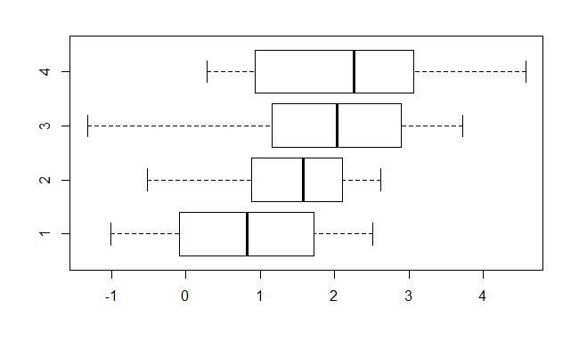

```r
group = rep(1:4, n)
boxplot(y1,y2,y3,y4, horizontal = TRUE)
```

```r
data = data.frame(y = y, group = factor(group))
fit = aov(y ~ group, data)
anova(fit)
```

```
Analysis of Variance Table

Response: y
          Df Sum Sq Mean Sq F value Pr(>F)
group      3 21.830  7.2766  5.7762 0.0013 **
Residuals 76 95.741  1.2598
---
Signif. codes:  0 â***â 0.001 â**â 0.01 â*â 0.05 â.â 0.1 â â 1
```

```r
TukeyHSD(fit)
```

```
  Tukey multiple comparisons of means
    95% family-wise confidence level

Fit: aov(formula = y ~ group, data = data)

$group
         diff         lwr      upr     p adj
2-1 0.6161300 -0.31619835 1.548458 0.3125193
3-1 1.0223160  0.08998765 1.954644 0.0259839
4-1 1.4114602  0.47913185 2.343789 0.0008936
3-2 0.4061860 -0.52614232 1.338514 0.6633700
4-2 0.7953302 -0.13699812 1.727659 0.1216064
4-3 0.3891442 -0.54318413 1.321473 0.6928076
```

Our F-value tell us that we have that much times between groups variance as within. It is the ratio of the two mean squares. And the mean squares come from the sum of squares divided by the degrees of freedom.

The TukeyHSD is a post-hoc that does a pair-wise comparison and takes into account the fact we’re doing multiple comparisons. It thereby protects from overinflating the chance of Type 1 error.

# Post-hoc tests

Post-hoc tests in general, allow for multiple pairwise comparisons without an increase in the probability of a Type 1 error.

Many procedures are available, the degree to which p-values are adjusted varies according to procedure. The most liberal involves no adjustment, the most conservative involves the Bonferoni procedure.

Because p = 0.05, if we do the same experiment over and over again, say 100 times to a population where there is no effect, I will get a significant value 5 times. This is what happens when we do multiple comparisons and is the reason we conduct post-hoc tests.

```r
# say for 6 possible pairwise comparisons
p.adjust(0.05,method = "bonferroni",6)
```

```
[1] 0.3
```

# Repeated Measures ANOVA

Previously we dealt with between samples ANOVA which is analagous to independent t tests. Repeated measures ANOVA is analagous to dependent t tests.

## Pros and cons of repeated measures ANOVA

### Pros

Less cost (fewer subjects required)

More statistical power. Subjects may reveal consistent individual differences across experiment i.e. the variance across subjects may be systematic. If so, it will not contribute to the error term.

In a between groups design we have two areas where variance can occur 1. the systematic / between groups variance or 2. unsystematic/ within groups variance.

In a repeated measures design we also have the subject variance. Thus, unsystematic/ within groups variance is reduced as a function of stable subject variance.

Error in a repeated measures design is the inconsistency of subjects from one condition to another.

$F_A=MS_A/MS_{A*S}$

where A is the variance attributable to your independent variable.

How much error did we create due to our manipulation is covered by the numerator term $MS_A$.

The error term in the denominator of the F ratio is mean squares for the interaction between your independent variable and subject variability.

## Mean Squares and F Ratio

$MS_A=SS_A/df_A$

$MS_{AxS}=SS_{AxS}/df_{AxS}$

$F=MS_A/MS_{AxS}$

# Repeated Measures ANOVA Example

Compare prices in local shops. List of ten representative grocery items and then went to four local stores and recorded the price of each item in each shop. The advantage of the repeated measures analysis is that it allows us to parcel out variability due to subjects. In this case the groceries.

```r
groceries = read.table(header=T, row.names=1, text="
 subject            storeA  storeB  storeC  storeD
 lettuce              1.17    1.78    1.29    1.29
 potatoes             1.77    1.98    1.99    1.99
 milk                 1.49    1.69    1.79    1.59
 eggs                 0.65    0.99    0.69    1.09
 bread                1.58    1.70    1.89    1.89
 cereal               3.13    3.15    2.99    3.09
 ground.beef          2.09    1.88    2.09    2.49
 tomato.soup          0.62    0.65    0.65    0.69
 laundry.detergent    5.89    5.99    5.99    6.99
 aspirin              4.46    4.84    4.99    5.15
 ")
gr2 = stack(groceries)                              # tidy up data
gr2$subject = rep(rownames(groceries), 4)           # create the "subject" variable
gr2$subject = factor(gr2$subject)                   # define the subject as factors
colnames(gr2) = c("price", "store", "subject")      # rename the columns
gr2                                                 # take a look
```

| price | store | subject |
| --- | --- | --- |
| 1.17 | storeA | lettuce |
| 1.77 | storeA | potatoes |
| 1.49 | storeA | milk |
| 0.65 | storeA | eggs |
| 1.58 | storeA | bread |
| 3.13 | storeA | cereal |
| 2.09 | storeA | ground.beef |
| 0.62 | storeA | tomato.soup |
| 5.89 | storeA | laundry.detergent |
| 4.46 | storeA | aspirin |

[output cut: 30 more lines]

```r
aov.out = aov(price ~ store + Error(subject/store), data=gr2)
summary(aov.out)
```

```
Error: subject
          Df Sum Sq Mean Sq F value Pr(>F)
Residuals  9  115.2    12.8

Error: subject:store
          Df Sum Sq Mean Sq F value Pr(>F)
store      3 0.5859 0.19529   4.344 0.0127 *
Residuals 27 1.2137 0.04495
---
Signif. codes:  0 â***â 0.001 â**â 0.01 â*â 0.05 â.â 0.1 â â 1
```

The first part of the summary is the subject variance.

The second part is the effect of our condition. The df for our condition is 3 because we have 4 shops.

We can then carry out our post hoc tests. In this case it’s the Holm method.

```r
with(gr2, pairwise.t.test(price,store, paired = T))
```

```
    Pairwise comparisons using paired t tests

data:  price and store

       storeA storeB storeC
storeB 0.17   -      -
storeC 0.17   0.69   -
storeD 0.07   0.49   0.33

P value adjustment method: holm
```

Here is the Bonferroni method:

```r
with(gr2, pairwise.t.test(price,store, paired = T,p.adjust.method = "bonferroni"))
```

```
    Pairwise comparisons using paired t tests

data:  price and store

       storeA storeB storeC
storeB 0.20   -      -
storeC 0.21   1.00   -
storeD 0.07   1.00   0.66

P value adjustment method: bonferroni
```